# Regressão na Votação

Thales Souto

22 de novembro de 2017

```r
library(ggplot2)
library(dplyr)
library(tidyr)
library(magrittr)
library(corrplot)
library(leaps)
```

```r
options(scipen = 4)
eleicoes <- read.csv("eleicoes2014.csv", encoding="latin1")
```

Para iniciar as questões, é importante que retiremos as variáveis com problemas:

```r
dados_problemas <- eleicoes %>% select(recursos_de_outros_candidatos.comites, recursos_de_partidos, recursos_de_pessoas_físicas, recursos_de_pessoas_juridicas, recursos_proprios)
summary(dados_problemas)
```

```
 recursos_de_outros_candidatos.comites recursos_de_partidos recursos_de_pessoas_físicas recursos_de_pessoas_juridicas recursos_proprios
 Min.   :      0.2                     Min.   :      0      Min.   :      0             Min.   :      1               Min.   :      0
 1st Qu.:   1101.2                     1st Qu.:   2030      1st Qu.:   1100             1st Qu.:   3000               1st Qu.:   1100
 Median :   4217.5                     Median :   6325      Median :   4550             Median :  28086               Median :   5019
 Mean   :  32403.3                     Mean   : 194633      Mean   :  39734             Mean   : 200014               Mean   :  44713
 3rd Qu.:  19150.0                     3rd Qu.: 105957      3rd Qu.:  28358             3rd Qu.: 201947               3rd Qu.:  22233
 Max.   :1788100.5                     Max.   :5769682      Max.   :1826762             Max.   :3532069               Max.   :3752000
 NA's   :1575                          NA's   :2286         NA's   :1148                NA's   :2778                  NA's   :1860
```

```r
eleicoes$recursos_de_outros_candidatos.comites[is.na(eleicoes$recursos_de_outros_candidatos.comites)]<-median (eleicoes$recursos_de_outros_candidatos.comites, na.rm = TRUE)

eleicoes$recursos_proprios[is.na(eleicoes$recursos_proprios)]<-median (eleicoes$recursos_proprios, na.rm = TRUE)

eleicoes$recursos_de_pessoas_físicas[is.na(eleicoes$recursos_de_pessoas_físicas)]<-median (eleicoes$recursos_de_pessoas_físicas, na.rm = TRUE)

eleicoes$recursos_de_pessoas_juridicas[is.na(eleicoes$recursos_de_pessoas_juridicas)]<-median (eleicoes$recursos_de_pessoas_juridicas, na.rm = TRUE)

eleicoes$recursos_de_partidos[is.na(eleicoes$recursos_de_partidos)]<-median (eleicoes$recursos_de_partidos, na.rm = TRUE)
```

## 1. Um modelo de regressão múltipla com todas as variáveis é plausível para explicar a variação em y (número de votos)?

Seria interessante filtrarmos os dados retirando todas as variáveis “inúteis”.

```r
filtra_dados <- eleicoes %>% select(-nome, -sequencial_candidato, -numero_cadidato, -cargo, -setor_economico_receita, -setor_economico_despesa)
```

Após isso transformamos variáveis categóricas em numéricas.

```r
filtra_dados$sexo <- as.numeric(filtra_dados$sexo)
filtra_dados$grau <- as.numeric(filtra_dados$grau)
filtra_dados$estado_civil <-as.numeric(filtra_dados$estado_civil)
filtra_dados$UF <-as.numeric(filtra_dados$UF)
#1=DEM, 2=PC do B, 3=PCB, 4=PCO, 5=PDT, 6=PEN, 7=PHS, 8=PMDB, 9 =PMN, 10=PP, 11=PPL, 12=PPS, 13=PR, 14=PRB, 15=PROS, #16=PRP, 17=PRTB, 18=PSB, 19=PSC, 20=PSD, 21=PSDB, 22=PSDC, 23=PSL, 24=PSOL, 25=PSTU, 26=PT, 27=PT do B, 28=PTB, #29=PTC, 30=PTN, 31=PV, 32=SD
filtra_dados$partido <-as.numeric(filtra_dados$partido)
filtra_dados_completo <- filtra_dados
```

Feito isso vamos calcular o p-valor das variáveis filtradas em relação a variável y (número de votos):

```r
t.test (filtra_dados$UF,filtra_dados$votos)
```

```
    Welch Two Sample t-test

data:  filtra_dados$UF and filtra_dados$votos
t = -24.534, df = 4151, p-value < 2.2e-16
alternative hypothesis: true difference in means is not equal to 0
95 percent confidence interval:
 -18619.50 -15863.93
sample estimates:
  mean of x   mean of y
   16.77336 17258.48675
```

```r
t.test (filtra_dados$partido,filtra_dados$votos)
```

```
    Welch Two Sample t-test

data:  filtra_dados$partido and filtra_dados$votos
t = -24.533, df = 4151, p-value < 2.2e-16
alternative hypothesis: true difference in means is not equal to 0
95 percent confidence interval:
 -18618.57 -15863.00
sample estimates:
  mean of x   mean of y
   17.70039 17258.48675
```

```r
t.test (filtra_dados$quantidade_doacoes,filtra_dados$votos)
```

```
    Welch Two Sample t-test

data:  filtra_dados$quantidade_doacoes and filtra_dados$votos
t = -24.525, df = 4151, p-value < 2.2e-16
alternative hypothesis: true difference in means is not equal to 0
95 percent confidence interval:
 -18612.71 -15857.14
sample estimates:
  mean of x   mean of y
   23.56551 17258.48675
```

```r
t.test (filtra_dados$quantidade_doadores,filtra_dados$votos)
```

```
    Welch Two Sample t-test

data:  filtra_dados$quantidade_doadores and filtra_dados$votos
t = -24.54, df = 4151, p-value < 2.2e-16
alternative hypothesis: true difference in means is not equal to 0
95 percent confidence interval:
 -18623.57 -15867.99
sample estimates:
  mean of x   mean of y
   12.70665 17258.48675
```

```r
t.test (filtra_dados$total_receita,filtra_dados$votos)
```

```
    Welch Two Sample t-test

data:  filtra_dados$total_receita and filtra_dados$votos
t = 21.22, df = 4193, p-value < 2.2e-16
alternative hypothesis: true difference in means is not equal to 0
95 percent confidence interval:
 190679.0 229499.9
sample estimates:
mean of x mean of y
227347.92  17258.49
```

```r
t.test (filtra_dados$media_receita,filtra_dados$votos)
```

```
    Welch Two Sample t-test

data:  filtra_dados$media_receita and filtra_dados$votos
t = -15.044, df = 5049.7, p-value < 2.2e-16
alternative hypothesis: true difference in means is not equal to 0
95 percent confidence interval:
 -12587.510  -9685.068
sample estimates:
mean of x mean of y
 6122.198 17258.487
```

```r
t.test (filtra_dados$recursos_de_outros_candidatos.comites,filtra_dados$votos)
```

```
    Welch Two Sample t-test

data:  filtra_dados$recursos_de_outros_candidatos.comites and filtra_dados$votos
t = 6.5646, df = 3109.7, p-value = 6.089e-11
alternative hypothesis: true difference in means is not equal to 0
95 percent confidence interval:
 10621.38 19668.32
sample estimates:
mean of x mean of y
 32403.34  17258.49
```

```r
t.test (filtra_dados$recursos_de_partidos,filtra_dados$votos)
```

```
    Welch Two Sample t-test

data:  filtra_dados$recursos_de_partidos and filtra_dados$votos
t = 15.09, df = 1878.4, p-value < 2.2e-16
alternative hypothesis: true difference in means is not equal to 0
95 percent confidence interval:
 154321.6 200427.0
sample estimates:
mean of x mean of y
194632.80  17258.49
```

```r
t.test (filtra_dados$recursos_de_pessoas_físicas,filtra_dados$votos)
```

```
    Welch Two Sample t-test

data:  filtra_dados$recursos_de_pessoas_físicas and filtra_dados$votos
t = 11.184, df = 3844.1, p-value < 2.2e-16
alternative hypothesis: true difference in means is not equal to 0
95 percent confidence interval:
 18535.76 26416.02
sample estimates:
mean of x mean of y
 39734.38  17258.49
```

```r
t.test (filtra_dados$recursos_de_pessoas_juridicas,filtra_dados$votos)
```

```
    Welch Two Sample t-test

data:  filtra_dados$recursos_de_pessoas_juridicas and filtra_dados$votos
t = 16.431, df = 1384, p-value < 2.2e-16
alternative hypothesis: true difference in means is not equal to 0
95 percent confidence interval:
 160936.5 204574.8
sample estimates:
mean of x mean of y
200014.12  17258.49
```

```r
t.test (filtra_dados$recursos_proprios,filtra_dados$votos)
```

```
    Welch Two Sample t-test

data:  filtra_dados$recursos_proprios and filtra_dados$votos
t = 6.9092, df = 2439.9, p-value = 6.195e-12
alternative hypothesis: true difference in means is not equal to 0
95 percent confidence interval:
 19662.60 35246.58
sample estimates:
mean of x mean of y
 44713.08  17258.49
```

```r
t.test (filtra_dados$quantidade_despesas,filtra_dados$votos)
```

```
    Welch Two Sample t-test

data:  filtra_dados$quantidade_despesas and filtra_dados$votos
t = -24.357, df = 4151.7, p-value < 2.2e-16
alternative hypothesis: true difference in means is not equal to 0
95 percent confidence interval:
 -18495.83 -15740.14
sample estimates:
 mean of x  mean of y
  140.4986 17258.4868
```

```r
t.test (filtra_dados$quantidade_fornecedores,filtra_dados$votos)
```

```
    Welch Two Sample t-test

data:  filtra_dados$quantidade_fornecedores and filtra_dados$votos
t = -24.459, df = 4151.2, p-value < 2.2e-16
alternative hypothesis: true difference in means is not equal to 0
95 percent confidence interval:
 -18566.99 -15811.38
sample estimates:
  mean of x   mean of y
   69.29986 17258.48675
```

```r
t.test (filtra_dados$total_despesa,filtra_dados$votos)
```

```
    Welch Two Sample t-test

data:  filtra_dados$total_despesa and filtra_dados$votos
t = 21.075, df = 4190.9, p-value < 2.2e-16
alternative hypothesis: true difference in means is not equal to 0
95 percent confidence interval:
 194207.5 234045.5
sample estimates:
mean of x mean of y
231385.00  17258.49
```

```r
t.test (filtra_dados$media_despesa,filtra_dados$votos)
```

```
    Welch Two Sample t-test

data:  filtra_dados$media_despesa and filtra_dados$votos
t = -22.766, df = 4162.2, p-value < 2.2e-16
alternative hypothesis: true difference in means is not equal to 0
95 percent confidence interval:
 -17388.47 -14631.04
sample estimates:
mean of x mean of y
 1248.732 17258.487
```

```r
t.test (filtra_dados$idade,filtra_dados$votos)
```

```
    Welch Two Sample t-test

data:  filtra_dados$idade and filtra_dados$votos
t = -24.49, df = 4151, p-value < 2.2e-16
alternative hypothesis: true difference in means is not equal to 0
95 percent confidence interval:
 -18588.43 -15832.86
sample estimates:
  mean of x   mean of y
   47.84658 17258.48675
```

```r
t.test (filtra_dados$sexo,filtra_dados$votos)
```

```
    Welch Two Sample t-test

data:  filtra_dados$sexo and filtra_dados$votos
t = -24.556, df = 4151, p-value < 2.2e-16
alternative hypothesis: true difference in means is not equal to 0
95 percent confidence interval:
 -18634.55 -15878.98
sample estimates:
   mean of x    mean of y
    1.723266 17258.486753
```

```r
t.test (filtra_dados$grau,filtra_dados$votos)
```

```
    Welch Two Sample t-test

data:  filtra_dados$grau and filtra_dados$votos
t = -24.551, df = 4151, p-value < 2.2e-16
alternative hypothesis: true difference in means is not equal to 0
95 percent confidence interval:
 -18631.31 -15875.74
sample estimates:
   mean of x    mean of y
    4.959538 17258.486753
```

```r
t.test (filtra_dados$estado_civil,filtra_dados$votos)
```

```
    Welch Two Sample t-test

data:  filtra_dados$estado_civil and filtra_dados$votos
t = -24.555, df = 4151, p-value < 2.2e-16
alternative hypothesis: true difference in means is not equal to 0
95 percent confidence interval:
 -18634.21 -15878.64
sample estimates:
   mean of x    mean of y
    2.060453 17258.486753
```

Observamos que todas as colunas restantes possuem um p-valor bem abaixo de 0.05.

## 2. Todas as variáveis são úteis para o modelo de regressão? Há variáveis redudantes? Justifique sua resposta em ambos os casos.

Para saber se temos variáveis redundantes devemos calcular a correlação entre variáveis que julgamos (manualmente) como parecidas:

```r
corr = cor(filtra_dados[, 1:20])
round(corr, 2)
```

```
                                         UF partido quantidade_doacoes quantidade_doadores total_receita media_receita
UF                                     1.00   -0.01               0.02                0.00         -0.02         -0.09
partido                               -0.01    1.00               0.03                0.04         -0.04         -0.08
quantidade_doacoes                     0.02    0.03               1.00                0.86          0.60          0.12
quantidade_doadores                    0.00    0.04               0.86                1.00          0.46          0.09
total_receita                         -0.02   -0.04               0.60                0.46          1.00          0.60
media_receita                         -0.09   -0.08               0.12                0.09          0.60          1.00
recursos_de_outros_candidatos.comites    NA      NA                 NA                  NA            NA            NA
recursos_de_partidos                     NA      NA                 NA                  NA            NA            NA
recursos_de_pessoas_físicas              NA      NA                 NA                  NA            NA            NA
recursos_de_pessoas_juridicas            NA      NA                 NA                  NA            NA            NA
recursos_proprios                        NA      NA                 NA                  NA            NA            NA
votos                                 -0.01   -0.04               0.48                0.42          0.62          0.43
quantidade_despesas                   -0.01   -0.02               0.58                0.48          0.81          0.38
quantidade_fornecedores               -0.04   -0.01               0.50                0.44          0.72          0.33
total_despesa                         -0.02   -0.04               0.60                0.46          0.99          0.59
media_despesa                         -0.11   -0.07               0.14                0.13          0.37          0.54
idade                                  0.01   -0.04               0.07                0.06          0.10          0.12
sexo                                   0.00    0.00               0.14                0.12          0.14          0.14
grau                                   0.00   -0.05               0.13                0.12          0.15          0.13
estado_civil                          -0.02    0.02              -0.11               -0.11         -0.11         -0.10
                                      recursos_de_outros_candidatos.comites recursos_de_partidos recursos_de_pessoas_físicas
UF                                                                       NA                   NA                          NA
partido                                                                  NA                   NA                          NA
quantidade_doacoes                                                       NA                   NA                          NA
quantidade_doadores                                                      NA                   NA                          NA
total_receita                                                            NA                   NA                          NA
media_receita                                                            NA                   NA                          NA
recursos_de_outros_candidatos.comites                                     1                   NA                          NA
recursos_de_partidos                                                     NA                    1                          NA
recursos_de_pessoas_físicas                                              NA                   NA                           1
recursos_de_pessoas_juridicas                                            NA                   NA                          NA
recursos_proprios                                                        NA                   NA                          NA
votos                                                                    NA                   NA                          NA
quantidade_despesas                                                      NA                   NA                          NA
quantidade_fornecedores                                                  NA                   NA                          NA
total_despesa                                                            NA                   NA                          NA
media_despesa                                                            NA                   NA                          NA
idade                                                                    NA                   NA                          NA
sexo                                                                     NA                   NA                          NA
```

[output cut: 29 more lines]

```
media_receita                                  0.59          0.54  0.12  0.14  0.13        -0.10
recursos_de_outros_candidatos.comites            NA            NA    NA    NA    NA           NA
recursos_de_partidos                             NA            NA    NA    NA    NA           NA
recursos_de_pessoas_físicas                      NA            NA    NA    NA    NA           NA
recursos_de_pessoas_juridicas                    NA            NA    NA    NA    NA           NA
recursos_proprios                                NA            NA    NA    NA    NA           NA
votos                                          0.61          0.30  0.09  0.16  0.14        -0.12
quantidade_despesas                            0.81          0.08  0.08  0.12  0.12        -0.09
quantidade_fornecedores                        0.72          0.05  0.07  0.09  0.10        -0.08
total_despesa                                  1.00          0.37  0.10  0.14  0.15        -0.11
media_despesa                                  0.37          1.00  0.10  0.12  0.11        -0.10
idade                                          0.10          0.10  1.00  0.12 -0.05        -0.24
sexo                                           0.14          0.12  0.12  1.00  0.05        -0.22
grau                                           0.15          0.11 -0.05  0.05  1.00        -0.04
estado_civil                                  -0.11         -0.10 -0.24 -0.22 -0.04         1.00
```

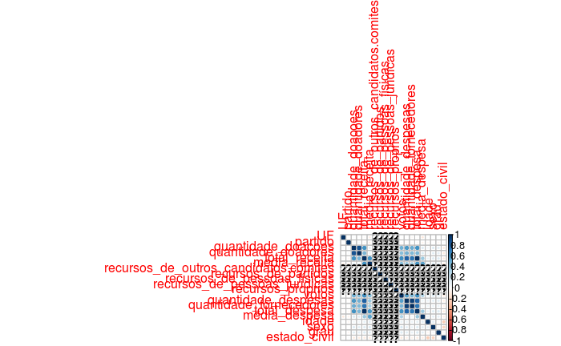

```r
corrplot(corr, method="circle")
```

Resposta: Nem todas as variáveis são úteis pois há variáveis redundantes, como foi mostrado pela forte correlação entre elas.

## 3. No caso de haver variáveis pouco explicativas e/ou redudantes, construa um novo modelo sem essas variáveis e o compare ao modelo com todas as variáveis (e.g. em termos de R2 e RSE).

Dados filtrados retirando as variáveis que julgamos redundantes na questão anterior:

```r
filtra_dados <- filtra_dados %>% select(-total_despesa, -quantidade_despesas)
```

Modelo com todas as variáveis:

```r
modelo_completo <- lm(formula = votos ~ ., filtra_dados_completo, na.action = na.omit)
summary(modelo_completo)
```

```
Call:
lm(formula = votos ~ ., data = filtra_dados_completo, na.action = na.omit)

Residuals:
    Min      1Q  Median      3Q     Max
-327449  -28128   -9247   23386 1039854

Coefficients:
                                         Estimate  Std. Error t value    Pr(>|t|)
(Intercept)                           -2585.69581 37414.94017  -0.069     0.94494
UF                                      550.48995   537.76408   1.024     0.30664
partido                                 121.75395   458.69827   0.265     0.79082
quantidade_doacoes                     -166.76357   112.26631  -1.485     0.13825
quantidade_doadores                     416.96604   152.25006   2.739     0.00646 **
total_receita                             1.44330     0.76366   1.890     0.05951 .
media_receita                             0.08275     0.33886   0.244     0.80722
recursos_de_outros_candidatos.comites    -1.23851     0.76211  -1.625     0.10496
recursos_de_partidos                     -1.44098     0.76647  -1.880     0.06086 .
recursos_de_pessoas_físicas              -1.47219     0.76730  -1.919     0.05577 .
recursos_de_pessoas_juridicas            -1.42487     0.76578  -1.861     0.06356 .
recursos_proprios                        -1.44825     0.76462  -1.894     0.05897 .
quantidade_despesas                      71.62985    14.13937   5.066 0.000000632 ***
quantidade_fornecedores                 -47.80721    19.04716  -2.510     0.01249 *
total_despesa                            -0.01936     0.02042  -0.948     0.34375
media_despesa                             8.92150     3.39389   2.629     0.00892 **
idade                                   201.48036   355.25874   0.567     0.57095
sexo                                   5447.63529 11828.74334   0.461     0.64539
grau                                   -529.61636  3093.68333  -0.171     0.86416
estado_civil                          -7363.45291  3415.94994  -2.156     0.03173 *
---
Signif. codes:  0 ‘***’ 0.001 ‘**’ 0.01 ‘*’ 0.05 ‘.’ 0.1 ‘ ’ 1

Residual standard error: 77320 on 384 degrees of freedom
  (3748 observations deleted due to missingness)
Multiple R-squared:  0.3331,    Adjusted R-squared:  0.3001
F-statistic:  10.1 on 19 and 384 DF,  p-value: < 2.2e-16
```

Modelo com as variáveis retiradas:

```r
modelo_filtrado <- lm(formula = votos ~ ., filtra_dados, na.action = na.omit)
summary(modelo_filtrado)
```

```
Call:
lm(formula = votos ~ ., data = filtra_dados, na.action = na.omit)

Residuals:
    Min      1Q  Median      3Q     Max
-253434  -32269   -9707   22496 1114947

Coefficients:
                                         Estimate  Std. Error t value Pr(>|t|)
(Intercept)                           10419.63529 38477.30350   0.271   0.7867
UF                                      534.60484   552.76402   0.967   0.3341
partido                                  28.29272   472.45270   0.060   0.9523
quantidade_doacoes                     -110.76326   113.69576  -0.974   0.3306
quantidade_doadores                     382.48263   154.89421   2.469   0.0140 *
total_receita                             1.62275     0.78393   2.070   0.0391 *
media_receita                             0.09335     0.34921   0.267   0.7894
recursos_de_outros_candidatos.comites    -1.41576     0.78054  -1.814   0.0705 .
recursos_de_partidos                     -1.61653     0.78494  -2.059   0.0401 *
recursos_de_pessoas_físicas              -1.67444     0.78559  -2.131   0.0337 *
recursos_de_pessoas_juridicas            -1.61230     0.78377  -2.057   0.0403 *
recursos_proprios                        -1.62164     0.78304  -2.071   0.0390 *
quantidade_fornecedores                  28.52421    12.13830   2.350   0.0193 *
media_despesa                             3.14172     3.29630   0.953   0.3411
idade                                    79.81059   365.37966   0.218   0.8272
sexo                                   6219.76752 12185.03463   0.510   0.6100
grau                                    397.70831  3182.95842   0.125   0.9006
estado_civil                          -6721.86142  3515.56342  -1.912   0.0566 .
---
Signif. codes:  0 ‘***’ 0.001 ‘**’ 0.01 ‘*’ 0.05 ‘.’ 0.1 ‘ ’ 1

Residual standard error: 79700 on 386 degrees of freedom
  (3748 observations deleted due to missingness)
Multiple R-squared:  0.2877,    Adjusted R-squared:  0.2564
F-statistic: 9.172 on 17 and 386 DF,  p-value: < 2.2e-16
```

## 4. Analise plots de resíduos e verifique se há tendências nos erros.

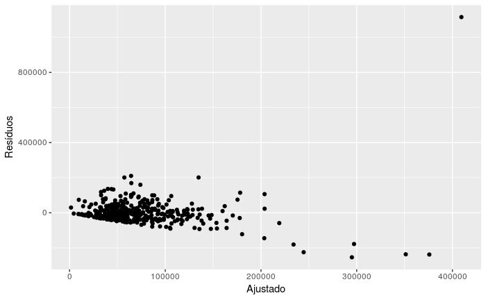

```r
ggplot(modelo_filtrado, aes(x = .fitted, y = .resid)) +
  geom_point() +
  xlab("Ajustado") +
  ylab("Resíduos")
```

Como citado em sala de aula, se os resíduos apresentarem valores próximos podemos afirmar que o modelo não é bom. O ideal seria que os pontos no gráficos estivessem bem espalhados.

## 5. Quais variáveis conseguem explicar melhor o número de votos?

Usaremos esta função para buscar qual melhor subconjunto entre as variáveis x que predizem y.

```r
sub_conjunto <-
    regsubsets(votos ~ .,
               data = filtra_dados,
               nbest = 1,
               nvmax = NULL,
               force.in = NULL, force.out = NULL,
               method = "exhaustive",
               really.big = T)
summary_sub_conjunto <- summary(sub_conjunto)
summary_sub_conjunto
```

```
Subset selection object
Call: regsubsets.formula(votos ~ ., data = filtra_dados, nbest = 1,
    nvmax = NULL, force.in = NULL, force.out = NULL, method = "exhaustive",
    really.big = T)
17 Variables  (and intercept)
                                      Forced in Forced out
UF                                        FALSE      FALSE
partido                                   FALSE      FALSE
quantidade_doacoes                        FALSE      FALSE
quantidade_doadores                       FALSE      FALSE
total_receita                             FALSE      FALSE
media_receita                             FALSE      FALSE
recursos_de_outros_candidatos.comites     FALSE      FALSE
recursos_de_partidos                      FALSE      FALSE
recursos_de_pessoas_físicas               FALSE      FALSE
recursos_de_pessoas_juridicas             FALSE      FALSE
recursos_proprios                         FALSE      FALSE
quantidade_fornecedores                   FALSE      FALSE
media_despesa                             FALSE      FALSE
idade                                     FALSE      FALSE
sexo                                      FALSE      FALSE
grau                                      FALSE      FALSE
estado_civil                              FALSE      FALSE
1 subsets of each size up to 17
Selection Algorithm: exhaustive
          UF  partido quantidade_doacoes quantidade_doadores total_receita media_receita recursos_de_outros_candidatos.comites
1  ( 1 )  " " " "     " "                " "                 " "           " "           "*"
2  ( 1 )  " " " "     " "                " "                 "*"           " "           "*"
3  ( 1 )  " " " "     " "                " "                 "*"           " "           "*"
4  ( 1 )  " " " "     " "                "*"                 "*"           " "           "*"
5  ( 1 )  " " " "     " "                "*"                 " "           " "           "*"
6  ( 1 )  " " " "     " "                "*"                 "*"           " "           "*"
7  ( 1 )  " " " "     " "                "*"                 "*"           " "           "*"
8  ( 1 )  "*" " "     " "                "*"                 "*"           " "           "*"
9  ( 1 )  " " " "     " "                "*"                 "*"           " "           "*"
10  ( 1 ) " " " "     "*"                "*"                 "*"           " "           "*"
11  ( 1 ) " " " "     "*"                "*"                 "*"           " "           "*"
12  ( 1 ) "*" " "     "*"                "*"                 "*"           " "           "*"
13  ( 1 ) "*" " "     "*"                "*"                 "*"           " "           "*"
14  ( 1 ) "*" " "     "*"                "*"                 "*"           "*"           "*"
```

[output cut: 24 more lines]

```
3  ( 1 )  " "           " "   " "  " "  "*"
4  ( 1 )  " "           " "   " "  " "  "*"
5  ( 1 )  " "           " "   " "  " "  "*"
6  ( 1 )  " "           " "   " "  " "  "*"
7  ( 1 )  "*"           " "   " "  " "  "*"
8  ( 1 )  "*"           " "   " "  " "  "*"
9  ( 1 )  " "           " "   " "  " "  "*"
10  ( 1 ) " "           " "   " "  " "  "*"
11  ( 1 ) "*"           " "   " "  " "  "*"
12  ( 1 ) "*"           " "   " "  " "  "*"
13  ( 1 ) "*"           " "   "*"  " "  "*"
14  ( 1 ) "*"           " "   "*"  " "  "*"
15  ( 1 ) "*"           "*"   "*"  " "  "*"
16  ( 1 ) "*"           "*"   "*"  "*"  "*"
17  ( 1 ) "*"           "*"   "*"  "*"  "*"
```

Feito isso, vamos agora avaliar quais variáveis melhor predizem y (número de votos):

```r
modelo_ideal <- which.max(summary_sub_conjunto$adjr2)
modelo_ideal
```

```
[1] 11
```

```r
summary_sub_conjunto$which[modelo_ideal,]
```

```
                          (Intercept)                                    UF                               partido
                                 TRUE                                 FALSE                                 FALSE
                   quantidade_doacoes                   quantidade_doadores                         total_receita
                                 TRUE                                  TRUE                                  TRUE
                        media_receita recursos_de_outros_candidatos.comites                  recursos_de_partidos
                                FALSE                                  TRUE                                  TRUE
          recursos_de_pessoas_físicas         recursos_de_pessoas_juridicas                     recursos_proprios
                                 TRUE                                  TRUE                                  TRUE
              quantidade_fornecedores                         media_despesa                                 idade
                                 TRUE                                  TRUE                                 FALSE
                                 sexo                                  grau                          estado_civil
                                FALSE                                 FALSE                                  TRUE
```

As variáveis com TRUE são as que melhor predizem o número de votos!